# Hg Fish_HF

CBG

12 11 2021

### Packages

The following packages are required - dplyr (for summarising data)

[output not shown]

## Model Hg in Fish

### Loading the data, two files (fish THg and other variables) for the three locations

- Sites cover: Ellasjøen, Mjøsa_Femunden, and Tollreien_Breidtjern
- TOC data available for Breidtjern and Pt for Vorma (Mjøsa/Femunden)

### SUbset data based on location

- for two stations, TOC/Pt data is attached
- Pt Vorma til Mjøsa?

### Explore data

- influential points?
- amounts of zeroes?
- colinearity: weight and length naturally covariates strongly. Should perhaps not be in the same model?
- Interactions between covariates
- linearity
- temporal autocorrelation

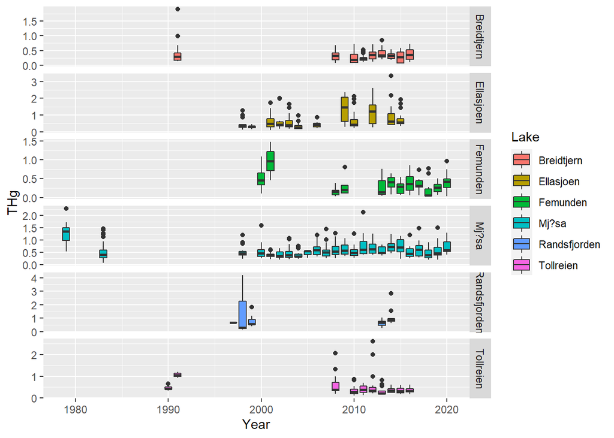

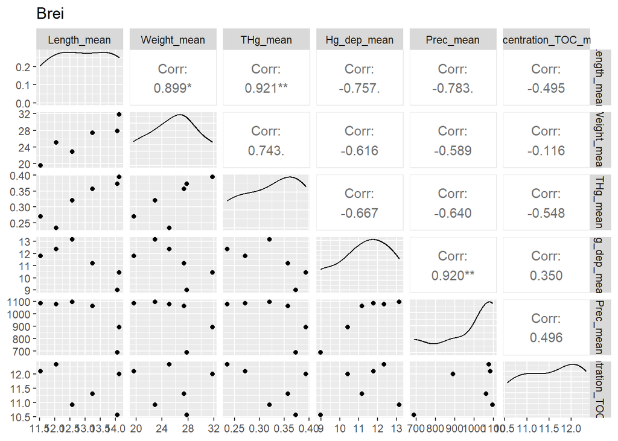

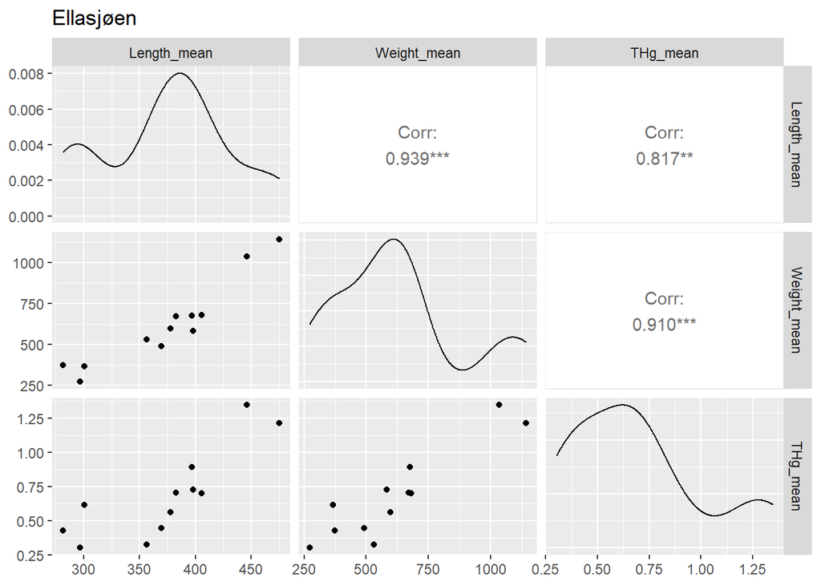

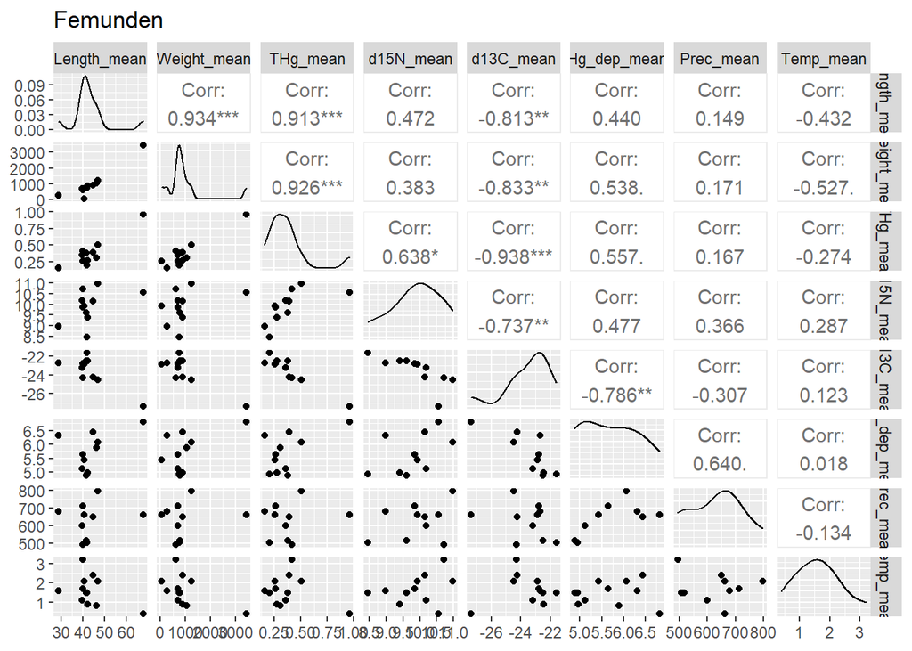

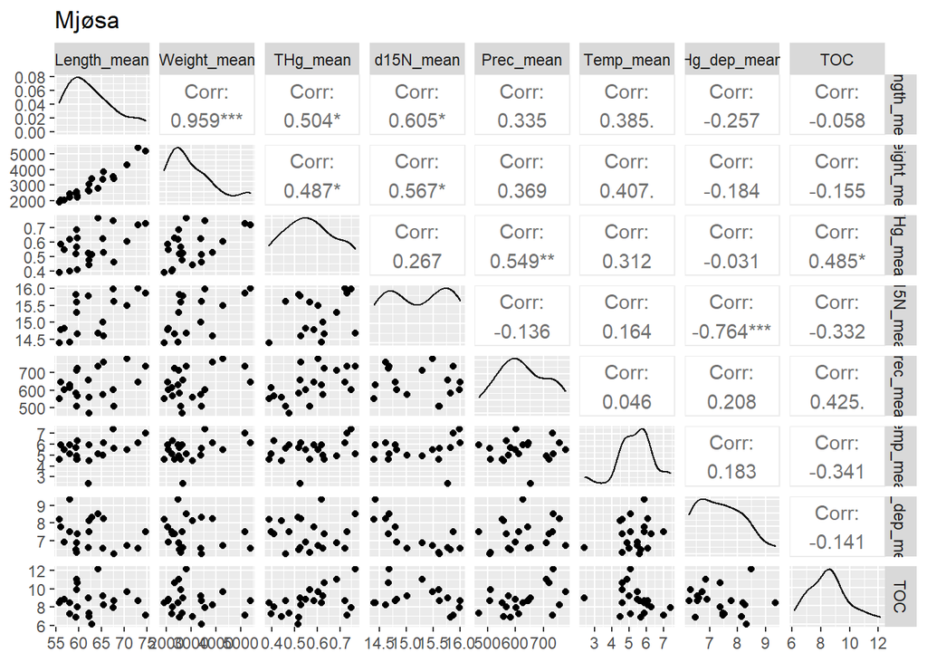

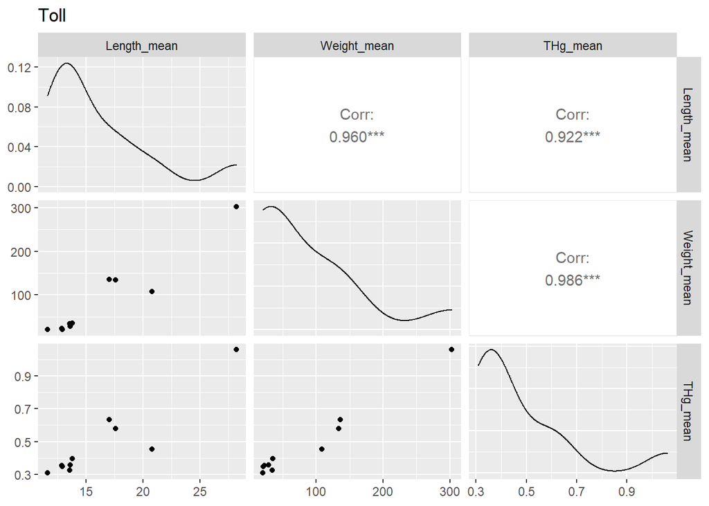

### Comment on colinearity - several of the parameters show colinearity (e.g. weight and length) - should not be inceluded in the same model - colinearity can further be expllored using e.g. ANOVA

### Generalized additive model

- incorporates nonlinear forms of the predictors
- using a smooth function of the predictor variables, which can take on a great many form
- the linear predictor now incorporates smooth functions of at least some (possibly all) covariates
- allows for nonlinear relationships between the covariates and the target variable y
- use models better suited to the situation, rather than torturing the data to fit a simplified modelling scheme
- GAMs are suspectible to extrapolation, as is every statistical method ever created
- composed of a sum of smiith functions of covaiates instead of or in addition to the standard linear covariate effects
- we are using a function s within the formula to denote the smooth terms
- we also specify the type of smooth, though a default is available. I chose bs = cr, denoting cubic regression splines

### General data adaptations, checking diagnostics

- qq plot for residuals, remover “outliers”
- transformation of the target variable, in case of heteroscedacity (not because of non-normality!) some might take the log
- it usually a good idea to scale predictor variables so that the effect is more meaningful